# Risk Factor Analysis

## Outcome Variable

**Outcome Variable:** ever_stunted

## Predictor Variables

**Intervention Variable:** pers_wast

**Adjustment Set:**

- arm
- sex
- W_mage
- meducyrs
- W_mhtcm
- month
- brthmon
- W_parity
- delta_W_mage
- delta_meducyrs
- delta_W_mhtcm
- delta_month
- delta_brthmon
- delta_W_parity

## Stratifying Variables

The analysis was stratified on these variable(s):

- agecat
- studyid
- country

## Data Summary

| agecat | studyid | country | pers_wast | ever_stunted | n_cell | n |
| --- | --- | --- | --- | --- | --- | --- |
| 0-6 months | ki0047075b-MAL-ED | BANGLADESH | 0 | 0 | 210 | 263 |
| 0-6 months | ki0047075b-MAL-ED | BANGLADESH | 0 | 1 | 44 | 263 |
| 0-6 months | ki0047075b-MAL-ED | BANGLADESH | 1 | 0 | 7 | 263 |
| 0-6 months | ki0047075b-MAL-ED | BANGLADESH | 1 | 1 | 2 | 263 |
| 0-6 months | ki0047075b-MAL-ED | BRAZIL | 0 | 0 | 207 | 233 |
| 0-6 months | ki0047075b-MAL-ED | BRAZIL | 0 | 1 | 25 | 233 |
| 0-6 months | ki0047075b-MAL-ED | BRAZIL | 1 | 0 | 1 | 233 |
| 0-6 months | ki0047075b-MAL-ED | BRAZIL | 1 | 1 | 0 | 233 |
| 0-6 months | ki0047075b-MAL-ED | INDIA | 0 | 0 | 190 | 251 |
| 0-6 months | ki0047075b-MAL-ED | INDIA | 0 | 1 | 40 | 251 |
| 0-6 months | ki0047075b-MAL-ED | INDIA | 1 | 0 | 19 | 251 |
| 0-6 months | ki0047075b-MAL-ED | INDIA | 1 | 1 | 2 | 251 |
| 0-6 months | ki0047075b-MAL-ED | NEPAL | 0 | 0 | 207 | 240 |
| 0-6 months | ki0047075b-MAL-ED | NEPAL | 0 | 1 | 28 | 240 |
| 0-6 months | ki0047075b-MAL-ED | NEPAL | 1 | 0 | 5 | 240 |
| 0-6 months | ki0047075b-MAL-ED | NEPAL | 1 | 1 | 0 | 240 |
| 0-6 months | ki0047075b-MAL-ED | PERU | 0 | 0 | 266 | 302 |
| 0-6 months | ki0047075b-MAL-ED | PERU | 0 | 1 | 36 | 302 |
| 0-6 months | ki0047075b-MAL-ED | SOUTH AFRICA | 0 | 0 | 273 | 313 |
| 0-6 months | ki0047075b-MAL-ED | SOUTH AFRICA | 0 | 1 | 33 | 313 |
| 0-6 months | ki0047075b-MAL-ED | SOUTH AFRICA | 1 | 0 | 7 | 313 |
| 0-6 months | ki0047075b-MAL-ED | SOUTH AFRICA | 1 | 1 | 0 | 313 |
| 0-6 months | ki0047075b-MAL-ED | TANZANIA, UNITED REPUBLIC OF | 0 | 0 | 219 | 261 |
| 0-6 months | ki0047075b-MAL-ED | TANZANIA, UNITED REPUBLIC OF | 0 | 1 | 42 | 261 |
| 0-6 months | ki1000108-CMC-V-BCS-2002 | INDIA | 0 | 0 | 252 | 368 |
| 0-6 months | ki1000108-CMC-V-BCS-2002 | INDIA | 0 | 1 | 61 | 368 |
| 0-6 months | ki1000108-CMC-V-BCS-2002 | INDIA | 1 | 0 | 40 | 368 |
| 0-6 months | ki1000108-CMC-V-BCS-2002 | INDIA | 1 | 1 | 15 | 368 |
| 0-6 months | ki1000108-IRC | INDIA | 0 | 0 | 295 | 410 |
| 0-6 months | ki1000108-IRC | INDIA | 0 | 1 | 44 | 410 |

[output cut: 180 more lines]

The following strata were considered:

- agecat: 0-24 months, studyid: ki0047075b-MAL-ED, country: BANGLADESH
- agecat: 0-24 months, studyid: ki0047075b-MAL-ED, country: BRAZIL
- agecat: 0-24 months, studyid: ki0047075b-MAL-ED, country: INDIA
- agecat: 0-24 months, studyid: ki0047075b-MAL-ED, country: NEPAL
- agecat: 0-24 months, studyid: ki0047075b-MAL-ED, country: PERU
- agecat: 0-24 months, studyid: ki0047075b-MAL-ED, country: SOUTH AFRICA
- agecat: 0-24 months, studyid: ki0047075b-MAL-ED, country: TANZANIA, UNITED REPUBLIC OF
- agecat: 0-24 months, studyid: ki1000108-CMC-V-BCS-2002, country: INDIA
- agecat: 0-24 months, studyid: ki1000108-IRC, country: INDIA
- agecat: 0-24 months, studyid: ki1000109-EE, country: PAKISTAN
- agecat: 0-24 months, studyid: ki1000109-ResPak, country: PAKISTAN
- agecat: 0-24 months, studyid: ki1017093b-PROVIDE, country: BANGLADESH
- agecat: 0-24 months, studyid: ki1066203-TanzaniaChild2, country: TANZANIA, UNITED REPUBLIC OF
- agecat: 0-24 months, studyid: ki1101329-Keneba, country: GAMBIA
- agecat: 0-24 months, studyid: ki1112895-Guatemala BSC, country: GUATEMALA
- agecat: 0-24 months, studyid: ki1113344-GMS-Nepal, country: NEPAL
- agecat: 0-24 months, studyid: ki1114097-CMIN, country: BANGLADESH
- agecat: 0-24 months, studyid: ki1114097-CMIN, country: PERU
- agecat: 0-24 months, studyid: ki1114097-CONTENT, country: PERU
- agecat: 0-6 months, studyid: ki0047075b-MAL-ED, country: BANGLADESH
- agecat: 0-6 months, studyid: ki0047075b-MAL-ED, country: BRAZIL
- agecat: 0-6 months, studyid: ki0047075b-MAL-ED, country: INDIA
- agecat: 0-6 months, studyid: ki0047075b-MAL-ED, country: NEPAL
- agecat: 0-6 months, studyid: ki0047075b-MAL-ED, country: PERU
- agecat: 0-6 months, studyid: ki0047075b-MAL-ED, country: SOUTH AFRICA
- agecat: 0-6 months, studyid: ki0047075b-MAL-ED, country: TANZANIA, UNITED REPUBLIC OF
- agecat: 0-6 months, studyid: ki1000108-CMC-V-BCS-2002, country: INDIA
- agecat: 0-6 months, studyid: ki1000108-IRC, country: INDIA
- agecat: 0-6 months, studyid: ki1000109-EE, country: PAKISTAN
- agecat: 0-6 months, studyid: ki1000109-ResPak, country: PAKISTAN
- agecat: 0-6 months, studyid: ki1017093b-PROVIDE, country: BANGLADESH
- agecat: 0-6 months, studyid: ki1066203-TanzaniaChild2, country: TANZANIA, UNITED REPUBLIC OF
- agecat: 0-6 months, studyid: ki1101329-Keneba, country: GAMBIA
- agecat: 0-6 months, studyid: ki1112895-Guatemala BSC, country: GUATEMALA
- agecat: 0-6 months, studyid: ki1113344-GMS-Nepal, country: NEPAL
- agecat: 0-6 months, studyid: ki1114097-CMIN, country: BANGLADESH
- agecat: 0-6 months, studyid: ki1114097-CMIN, country: PERU
- agecat: 0-6 months, studyid: ki1114097-CONTENT, country: PERU
- agecat: 6-24 months, studyid: ki0047075b-MAL-ED, country: BANGLADESH
- agecat: 6-24 months, studyid: ki0047075b-MAL-ED, country: BRAZIL
- agecat: 6-24 months, studyid: ki0047075b-MAL-ED, country: INDIA
- agecat: 6-24 months, studyid: ki0047075b-MAL-ED, country: NEPAL
- agecat: 6-24 months, studyid: ki0047075b-MAL-ED, country: PERU
- agecat: 6-24 months, studyid: ki0047075b-MAL-ED, country: SOUTH AFRICA
- agecat: 6-24 months, studyid: ki0047075b-MAL-ED, country: TANZANIA, UNITED REPUBLIC OF
- agecat: 6-24 months, studyid: ki1000108-CMC-V-BCS-2002, country: INDIA
- agecat: 6-24 months, studyid: ki1000108-IRC, country: INDIA
- agecat: 6-24 months, studyid: ki1000109-EE, country: PAKISTAN
- agecat: 6-24 months, studyid: ki1000109-ResPak, country: PAKISTAN
- agecat: 6-24 months, studyid: ki1017093b-PROVIDE, country: BANGLADESH
- agecat: 6-24 months, studyid: ki1066203-TanzaniaChild2, country: TANZANIA, UNITED REPUBLIC OF
- agecat: 6-24 months, studyid: ki1101329-Keneba, country: GAMBIA
- agecat: 6-24 months, studyid: ki1112895-Guatemala BSC, country: GUATEMALA
- agecat: 6-24 months, studyid: ki1113344-GMS-Nepal, country: NEPAL
- agecat: 6-24 months, studyid: ki1114097-CMIN, country: BANGLADESH
- agecat: 6-24 months, studyid: ki1114097-CMIN, country: PERU
- agecat: 6-24 months, studyid: ki1114097-CONTENT, country: PERU

### Dropped Strata

Some strata were dropped due to rare outcomes:

- agecat: 0-6 months, studyid: ki0047075b-MAL-ED, country: BANGLADESH
- agecat: 0-6 months, studyid: ki0047075b-MAL-ED, country: BRAZIL
- agecat: 0-6 months, studyid: ki0047075b-MAL-ED, country: INDIA
- agecat: 0-6 months, studyid: ki0047075b-MAL-ED, country: NEPAL
- agecat: 0-6 months, studyid: ki0047075b-MAL-ED, country: SOUTH AFRICA
- agecat: 0-6 months, studyid: ki1017093b-PROVIDE, country: BANGLADESH
- agecat: 0-6 months, studyid: ki1066203-TanzaniaChild2, country: TANZANIA, UNITED REPUBLIC OF
- agecat: 0-6 months, studyid: ki1112895-Guatemala BSC, country: GUATEMALA
- agecat: 0-6 months, studyid: ki1114097-CMIN, country: PERU
- agecat: 6-24 months, studyid: ki0047075b-MAL-ED, country: BANGLADESH
- agecat: 6-24 months, studyid: ki0047075b-MAL-ED, country: BRAZIL
- agecat: 6-24 months, studyid: ki0047075b-MAL-ED, country: INDIA
- agecat: 6-24 months, studyid: ki0047075b-MAL-ED, country: NEPAL
- agecat: 6-24 months, studyid: ki0047075b-MAL-ED, country: SOUTH AFRICA
- agecat: 6-24 months, studyid: ki1000109-EE, country: PAKISTAN
- agecat: 6-24 months, studyid: ki1017093b-PROVIDE, country: BANGLADESH
- agecat: 6-24 months, studyid: ki1066203-TanzaniaChild2, country: TANZANIA, UNITED REPUBLIC OF
- agecat: 6-24 months, studyid: ki1112895-Guatemala BSC, country: GUATEMALA
- agecat: 6-24 months, studyid: ki1114097-CMIN, country: BANGLADESH
- agecat: 6-24 months, studyid: ki1114097-CMIN, country: PERU
- agecat: 0-24 months, studyid: ki0047075b-MAL-ED, country: BANGLADESH
- agecat: 0-24 months, studyid: ki0047075b-MAL-ED, country: BRAZIL
- agecat: 0-24 months, studyid: ki0047075b-MAL-ED, country: NEPAL
- agecat: 0-24 months, studyid: ki0047075b-MAL-ED, country: SOUTH AFRICA
- agecat: 0-24 months, studyid: ki1000108-CMC-V-BCS-2002, country: INDIA
- agecat: 0-24 months, studyid: ki1000109-EE, country: PAKISTAN
- agecat: 0-24 months, studyid: ki1112895-Guatemala BSC, country: GUATEMALA
- agecat: 0-24 months, studyid: ki1114097-CMIN, country: BANGLADESH

## Methods Detail

We’re interested in the causal parameters $E[Y_a]$ for all values of $a \in \mathcal{A}$. These parameters represent the mean outcome if, possibly contrary to fact, we intervened to set all units to have $A=a$. Under the randomization and positivity assumptions, these are identified by the statistical parameters $\psi_a=E_W[E_{Y|A,W}(Y|A=a,W)]$. In addition, we’re interested in the mean of $Y$, $E[Y]$ under no intervention (the observed mean). We will estimate these parameters by using SuperLearner to fit the relevant likelihood factors – $E_{Y|A,W}(Y|A=a,W)$ and $p(A=a|W)$, and then updating our likelihood fit using a joint TMLE.

For unadjusted analyses ($W=\{\}$), initial likelihoods were estimated using Lrnr_glm to estimate the simple $E(Y|A)$ and Lrnr_mean to estimate $p(A)$. For adjusted analyses, a small library containing Lrnr_glmnet, Lrnr_xgboost, and Lrnr_mean was used.

Having estimated these parameters, we will then use the delta method to estimate relative risks and attributable risks relative to a prespecified baseline level of $A$.

[output not shown]

# Results Detail

## Results Plots

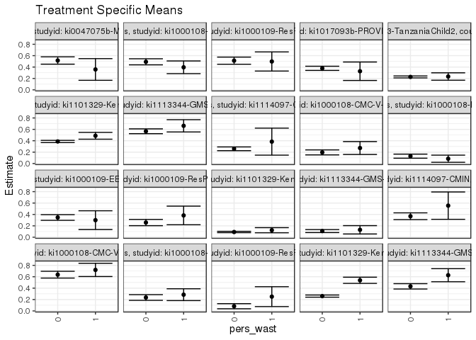

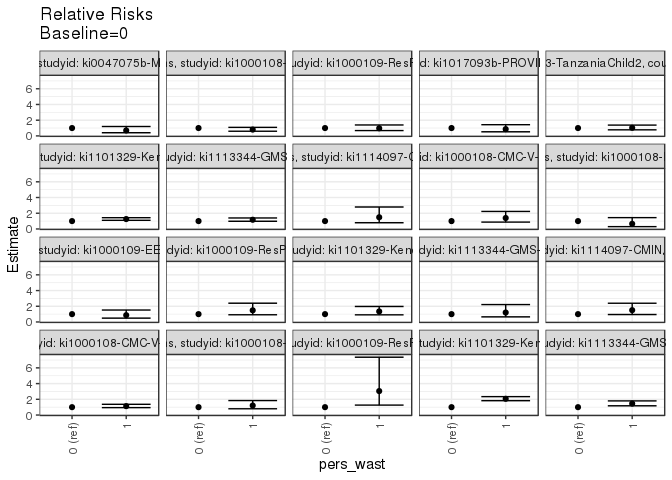

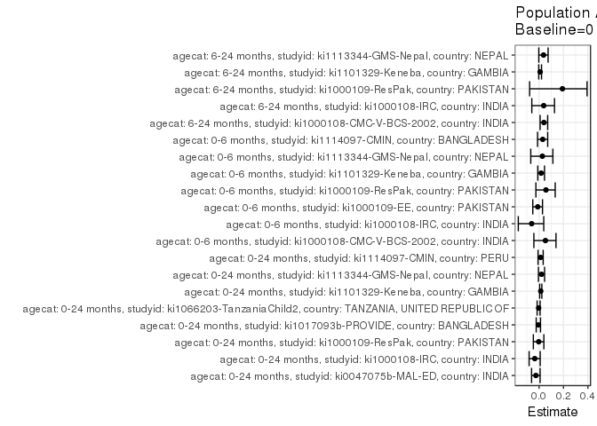

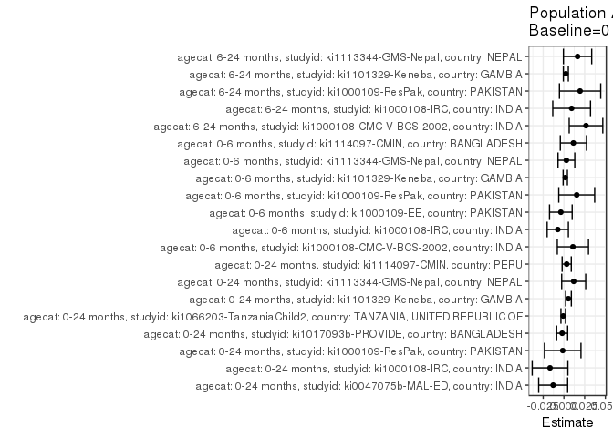

## Results Table

### Parameter: TSM

| agecat | studyid | country | intervention_level | baseline_level | estimate | ci_lower | ci_upper |
| --- | --- | --- | --- | --- | --- | --- | --- |
| 0-24 months | ki0047075b-MAL-ED | INDIA | 0 | NA | 0.5149495 | 0.4505204 | 0.5793785 |
| 0-24 months | ki0047075b-MAL-ED | INDIA | 1 | NA | 0.3579093 | 0.1675590 | 0.5482595 |
| 0-24 months | ki1000108-IRC | INDIA | 0 | NA | 0.4923364 | 0.4391046 | 0.5455682 |
| 0-24 months | ki1000108-IRC | INDIA | 1 | NA | 0.3958036 | 0.2845350 | 0.5070723 |
| 0-24 months | ki1000109-ResPak | PAKISTAN | 0 | NA | 0.5122326 | 0.4493872 | 0.5750779 |
| 0-24 months | ki1000109-ResPak | PAKISTAN | 1 | NA | 0.4978531 | 0.3301418 | 0.6655644 |
| 0-24 months | ki1017093b-PROVIDE | BANGLADESH | 0 | NA | 0.3778351 | 0.3412635 | 0.4144067 |
| 0-24 months | ki1017093b-PROVIDE | BANGLADESH | 1 | NA | 0.3265880 | 0.1645746 | 0.4886014 |
| 0-24 months | ki1066203-TanzaniaChild2 | TANZANIA, UNITED REPUBLIC OF | 0 | NA | 0.2266390 | 0.2096616 | 0.2436163 |
| 0-24 months | ki1066203-TanzaniaChild2 | TANZANIA, UNITED REPUBLIC OF | 1 | NA | 0.2339881 | 0.1691311 | 0.2988451 |
| 0-24 months | ki1101329-Keneba | GAMBIA | 0 | NA | 0.3873660 | 0.3678786 | 0.4068534 |
| 0-24 months | ki1101329-Keneba | GAMBIA | 1 | NA | 0.4871756 | 0.4275727 | 0.5467786 |
| 0-24 months | ki1113344-GMS-Nepal | NEPAL | 0 | NA | 0.5662879 | 0.5239809 | 0.6085948 |
| 0-24 months | ki1113344-GMS-Nepal | NEPAL | 1 | NA | 0.6621622 | 0.5543098 | 0.7700145 |
| 0-24 months | ki1114097-CMIN | PERU | 0 | NA | 0.2584251 | 0.2256043 | 0.2912459 |
| 0-24 months | ki1114097-CMIN | PERU | 1 | NA | 0.3844336 | 0.1472591 | 0.6216080 |
| 0-6 months | ki1000108-CMC-V-BCS-2002 | INDIA | 0 | NA | 0.1956928 | 0.1519227 | 0.2394630 |
| 0-6 months | ki1000108-CMC-V-BCS-2002 | INDIA | 1 | NA | 0.2724265 | 0.1593670 | 0.3854860 |
| 0-6 months | ki1000108-IRC | INDIA | 0 | NA | 0.1293638 | 0.0936616 | 0.1650660 |
| 0-6 months | ki1000108-IRC | INDIA | 1 | NA | 0.0846922 | 0.0219068 | 0.1474775 |
| 0-6 months | ki1000109-EE | PAKISTAN | 0 | NA | 0.3467049 | 0.2967079 | 0.3967019 |
| 0-6 months | ki1000109-EE | PAKISTAN | 1 | NA | 0.3000000 | 0.1358009 | 0.4641991 |
| 0-6 months | ki1000109-ResPak | PAKISTAN | 0 | NA | 0.2579362 | 0.2029547 | 0.3129177 |
| 0-6 months | ki1000109-ResPak | PAKISTAN | 1 | NA | 0.3826255 | 0.2192016 | 0.5460495 |
| 0-6 months | ki1101329-Keneba | GAMBIA | 0 | NA | 0.0917159 | 0.0801656 | 0.1032661 |
| 0-6 months | ki1101329-Keneba | GAMBIA | 1 | NA | 0.1229932 | 0.0778690 | 0.1681173 |
| 0-6 months | ki1113344-GMS-Nepal | NEPAL | 0 | NA | 0.1083046 | 0.0819241 | 0.1346851 |
| 0-6 months | ki1113344-GMS-Nepal | NEPAL | 1 | NA | 0.1303262 | 0.0569430 | 0.2037093 |
| 0-6 months | ki1114097-CMIN | BANGLADESH | 0 | NA | 0.3686462 | 0.3093031 | 0.4279893 |
| 0-6 months | ki1114097-CMIN | BANGLADESH | 1 | NA | 0.5545936 | 0.3142496 | 0.7949375 |
| 6-24 months | ki1000108-CMC-V-BCS-2002 | INDIA | 0 | NA | 0.6365301 | 0.5766281 | 0.6964320 |
| 6-24 months | ki1000108-CMC-V-BCS-2002 | INDIA | 1 | NA | 0.7201144 | 0.6038070 | 0.8364218 |
| 6-24 months | ki1000108-IRC | INDIA | 0 | NA | 0.2355304 | 0.1854189 | 0.2856419 |
| 6-24 months | ki1000108-IRC | INDIA | 1 | NA | 0.2851042 | 0.1815424 | 0.3886660 |
| 6-24 months | ki1000109-ResPak | PAKISTAN | 0 | NA | 0.0823034 | 0.0374555 | 0.1271513 |
| 6-24 months | ki1000109-ResPak | PAKISTAN | 1 | NA | 0.2507983 | 0.0762087 | 0.4253879 |
| 6-24 months | ki1101329-Keneba | GAMBIA | 0 | NA | 0.2602315 | 0.2409100 | 0.2795529 |
| 6-24 months | ki1101329-Keneba | GAMBIA | 1 | NA | 0.5377198 | 0.4833286 | 0.5921110 |
| 6-24 months | ki1113344-GMS-Nepal | NEPAL | 0 | NA | 0.4314613 | 0.3842727 | 0.4786500 |
| 6-24 months | ki1113344-GMS-Nepal | NEPAL | 1 | NA | 0.6270742 | 0.5121564 | 0.7419919 |

### Parameter: E(Y)

| agecat | studyid | country | intervention_level | baseline_level | estimate | ci_lower | ci_upper |
| --- | --- | --- | --- | --- | --- | --- | --- |
| 0-24 months | ki0047075b-MAL-ED | INDIA | NA | NA | 0.5019920 | 0.4400130 | 0.5639710 |
| 0-24 months | ki1000108-IRC | INDIA | NA | NA | 0.4756098 | 0.4272105 | 0.5240091 |
| 0-24 months | ki1000109-ResPak | PAKISTAN | NA | NA | 0.5107914 | 0.4519237 | 0.5696591 |
| 0-24 months | ki1017093b-PROVIDE | BANGLADESH | NA | NA | 0.3757143 | 0.3398113 | 0.4116172 |
| 0-24 months | ki1066203-TanzaniaChild2 | TANZANIA, UNITED REPUBLIC OF | NA | NA | 0.2257930 | 0.2090482 | 0.2425378 |
| 0-24 months | ki1101329-Keneba | GAMBIA | NA | NA | 0.3928571 | 0.3735695 | 0.4121448 |
| 0-24 months | ki1113344-GMS-Nepal | NEPAL | NA | NA | 0.5780731 | 0.5385891 | 0.6175571 |
| 0-24 months | ki1114097-CMIN | PERU | NA | NA | 0.2618026 | 0.2291894 | 0.2944158 |
| 0-6 months | ki1000108-CMC-V-BCS-2002 | INDIA | NA | NA | 0.2065217 | 0.1651060 | 0.2479375 |
| 0-6 months | ki1000108-IRC | INDIA | NA | NA | 0.1219512 | 0.0902381 | 0.1536643 |
| 0-6 months | ki1000109-EE | PAKISTAN | NA | NA | 0.3430079 | 0.2951521 | 0.3908637 |
| 0-6 months | ki1000109-ResPak | PAKISTAN | NA | NA | 0.2733813 | 0.2208950 | 0.3258676 |
| 0-6 months | ki1101329-Keneba | GAMBIA | NA | NA | 0.0933442 | 0.0818552 | 0.1048331 |
| 0-6 months | ki1113344-GMS-Nepal | NEPAL | NA | NA | 0.1112957 | 0.0861520 | 0.1364394 |
| 0-6 months | ki1114097-CMIN | BANGLADESH | NA | NA | 0.3800738 | 0.3221749 | 0.4379727 |
| 6-24 months | ki1000108-CMC-V-BCS-2002 | INDIA | NA | NA | 0.6631579 | 0.6081898 | 0.7181260 |
| 6-24 months | ki1000108-IRC | INDIA | NA | NA | 0.2448378 | 0.1989973 | 0.2906782 |
| 6-24 months | ki1000109-ResPak | PAKISTAN | NA | NA | 0.1017964 | 0.0557975 | 0.1477953 |
| 6-24 months | ki1101329-Keneba | GAMBIA | NA | NA | 0.2625559 | 0.2433195 | 0.2817924 |
| 6-24 months | ki1113344-GMS-Nepal | NEPAL | NA | NA | 0.4479167 | 0.4033837 | 0.4924496 |

### Parameter: RR

| agecat | studyid | country | intervention_level | baseline_level | estimate | ci_lower | ci_upper |
| --- | --- | --- | --- | --- | --- | --- | --- |
| 0-24 months | ki0047075b-MAL-ED | INDIA | 0 | 0 | 1.0000000 | 1.0000000 | 1.000000 |
| 0-24 months | ki0047075b-MAL-ED | INDIA | 1 | 0 | 0.6950376 | 0.4040798 | 1.195500 |
| 0-24 months | ki1000108-IRC | INDIA | 0 | 0 | 1.0000000 | 1.0000000 | 1.000000 |
| 0-24 months | ki1000108-IRC | INDIA | 1 | 0 | 0.8039293 | 0.5956305 | 1.085073 |
| 0-24 months | ki1000109-ResPak | PAKISTAN | 0 | 0 | 1.0000000 | 1.0000000 | 1.000000 |
| 0-24 months | ki1000109-ResPak | PAKISTAN | 1 | 0 | 0.9719279 | 0.6790701 | 1.391085 |
| 0-24 months | ki1017093b-PROVIDE | BANGLADESH | 0 | 0 | 1.0000000 | 1.0000000 | 1.000000 |
| 0-24 months | ki1017093b-PROVIDE | BANGLADESH | 1 | 0 | 0.8643665 | 0.5226287 | 1.429561 |
| 0-24 months | ki1066203-TanzaniaChild2 | TANZANIA, UNITED REPUBLIC OF | 0 | 0 | 1.0000000 | 1.0000000 | 1.000000 |
| 0-24 months | ki1066203-TanzaniaChild2 | TANZANIA, UNITED REPUBLIC OF | 1 | 0 | 1.0324267 | 0.7752443 | 1.374928 |
| 0-24 months | ki1101329-Keneba | GAMBIA | 0 | 0 | 1.0000000 | 1.0000000 | 1.000000 |
| 0-24 months | ki1101329-Keneba | GAMBIA | 1 | 0 | 1.2576624 | 1.1032334 | 1.433708 |
| 0-24 months | ki1113344-GMS-Nepal | NEPAL | 0 | 0 | 1.0000000 | 1.0000000 | 1.000000 |
| 0-24 months | ki1113344-GMS-Nepal | NEPAL | 1 | 0 | 1.1693031 | 0.9774700 | 1.398784 |
| 0-24 months | ki1114097-CMIN | PERU | 0 | 0 | 1.0000000 | 1.0000000 | 1.000000 |
| 0-24 months | ki1114097-CMIN | PERU | 1 | 0 | 1.4876013 | 0.7924265 | 2.792635 |
| 0-6 months | ki1000108-CMC-V-BCS-2002 | INDIA | 0 | 0 | 1.0000000 | 1.0000000 | 1.000000 |
| 0-6 months | ki1000108-CMC-V-BCS-2002 | INDIA | 1 | 0 | 1.3921130 | 0.8703339 | 2.226707 |
| 0-6 months | ki1000108-IRC | INDIA | 0 | 0 | 1.0000000 | 1.0000000 | 1.000000 |
| 0-6 months | ki1000108-IRC | INDIA | 1 | 0 | 0.6546821 | 0.2972623 | 1.441853 |
| 0-6 months | ki1000109-EE | PAKISTAN | 0 | 0 | 1.0000000 | 1.0000000 | 1.000000 |
| 0-6 months | ki1000109-EE | PAKISTAN | 1 | 0 | 0.8652893 | 0.4913001 | 1.523968 |
| 0-6 months | ki1000109-ResPak | PAKISTAN | 0 | 0 | 1.0000000 | 1.0000000 | 1.000000 |
| 0-6 months | ki1000109-ResPak | PAKISTAN | 1 | 0 | 1.4834115 | 0.9203719 | 2.390892 |
| 0-6 months | ki1101329-Keneba | GAMBIA | 0 | 0 | 1.0000000 | 1.0000000 | 1.000000 |
| 0-6 months | ki1101329-Keneba | GAMBIA | 1 | 0 | 1.3410238 | 0.9109548 | 1.974132 |
| 0-6 months | ki1113344-GMS-Nepal | NEPAL | 0 | 0 | 1.0000000 | 1.0000000 | 1.000000 |
| 0-6 months | ki1113344-GMS-Nepal | NEPAL | 1 | 0 | 1.2033298 | 0.6526586 | 2.218622 |
| 0-6 months | ki1114097-CMIN | BANGLADESH | 0 | 0 | 1.0000000 | 1.0000000 | 1.000000 |
| 0-6 months | ki1114097-CMIN | BANGLADESH | 1 | 0 | 1.5044060 | 0.9475547 | 2.388503 |
| 6-24 months | ki1000108-CMC-V-BCS-2002 | INDIA | 0 | 0 | 1.0000000 | 1.0000000 | 1.000000 |
| 6-24 months | ki1000108-CMC-V-BCS-2002 | INDIA | 1 | 0 | 1.1313125 | 0.9384630 | 1.363792 |
| 6-24 months | ki1000108-IRC | INDIA | 0 | 0 | 1.0000000 | 1.0000000 | 1.000000 |
| 6-24 months | ki1000108-IRC | INDIA | 1 | 0 | 1.2104772 | 0.7955068 | 1.841914 |
| 6-24 months | ki1000109-ResPak | PAKISTAN | 0 | 0 | 1.0000000 | 1.0000000 | 1.000000 |
| 6-24 months | ki1000109-ResPak | PAKISTAN | 1 | 0 | 3.0472406 | 1.2618944 | 7.358520 |
| 6-24 months | ki1101329-Keneba | GAMBIA | 0 | 0 | 1.0000000 | 1.0000000 | 1.000000 |
| 6-24 months | ki1101329-Keneba | GAMBIA | 1 | 0 | 2.0663135 | 1.8259575 | 2.338308 |
| 6-24 months | ki1113344-GMS-Nepal | NEPAL | 0 | 0 | 1.0000000 | 1.0000000 | 1.000000 |
| 6-24 months | ki1113344-GMS-Nepal | NEPAL | 1 | 0 | 1.4533727 | 1.1745492 | 1.798385 |

### Parameter: PAR

| agecat | studyid | country | intervention_level | baseline_level | estimate | ci_lower | ci_upper |
| --- | --- | --- | --- | --- | --- | --- | --- |
| 0-24 months | ki0047075b-MAL-ED | INDIA | 0 | NA | -0.0129575 | -0.0304171 | 0.0045021 |
| 0-24 months | ki1000108-IRC | INDIA | 0 | NA | -0.0167267 | -0.0382513 | 0.0047980 |
| 0-24 months | ki1000109-ResPak | PAKISTAN | 0 | NA | -0.0014412 | -0.0234431 | 0.0205607 |
| 0-24 months | ki1017093b-PROVIDE | BANGLADESH | 0 | NA | -0.0021208 | -0.0087513 | 0.0045097 |
| 0-24 months | ki1066203-TanzaniaChild2 | TANZANIA, UNITED REPUBLIC OF | 0 | NA | -0.0008460 | -0.0035919 | 0.0019000 |
| 0-24 months | ki1101329-Keneba | GAMBIA | 0 | NA | 0.0054912 | 0.0020303 | 0.0089521 |
| 0-24 months | ki1113344-GMS-Nepal | NEPAL | 0 | NA | 0.0117852 | -0.0026766 | 0.0262470 |
| 0-24 months | ki1114097-CMIN | PERU | 0 | NA | 0.0033774 | -0.0021441 | 0.0088990 |
| 0-6 months | ki1000108-CMC-V-BCS-2002 | INDIA | 0 | NA | 0.0108289 | -0.0079590 | 0.0296168 |
| 0-6 months | ki1000108-IRC | INDIA | 0 | NA | -0.0074126 | -0.0202105 | 0.0053853 |
| 0-6 months | ki1000109-EE | PAKISTAN | 0 | NA | -0.0036970 | -0.0173427 | 0.0099488 |
| 0-6 months | ki1000109-ResPak | PAKISTAN | 0 | NA | 0.0154451 | -0.0061990 | 0.0370892 |
| 0-6 months | ki1101329-Keneba | GAMBIA | 0 | NA | 0.0016283 | -0.0009414 | 0.0041980 |
| 0-6 months | ki1113344-GMS-Nepal | NEPAL | 0 | NA | 0.0029911 | -0.0071033 | 0.0130855 |
| 0-6 months | ki1114097-CMIN | BANGLADESH | 0 | NA | 0.0114276 | -0.0043439 | 0.0271991 |
| 6-24 months | ki1000108-CMC-V-BCS-2002 | INDIA | 0 | NA | 0.0266278 | 0.0063788 | 0.0468769 |
| 6-24 months | ki1000108-IRC | INDIA | 0 | NA | 0.0093074 | -0.0134367 | 0.0320514 |
| 6-24 months | ki1000109-ResPak | PAKISTAN | 0 | NA | 0.0194930 | -0.0053920 | 0.0443780 |
| 6-24 months | ki1101329-Keneba | GAMBIA | 0 | NA | 0.0023245 | -0.0006810 | 0.0053300 |
| 6-24 months | ki1113344-GMS-Nepal | NEPAL | 0 | NA | 0.0164553 | -0.0005873 | 0.0334980 |

### Parameter: PAF

| agecat | studyid | country | intervention_level | baseline_level | estimate | ci_lower | ci_upper |
| --- | --- | --- | --- | --- | --- | --- | --- |
| 0-24 months | ki0047075b-MAL-ED | INDIA | 0 | NA | -0.0258121 | -0.0613324 | 0.0085195 |
| 0-24 months | ki1000108-IRC | INDIA | 0 | NA | -0.0351689 | -0.0815276 | 0.0092027 |
| 0-24 months | ki1000109-ResPak | PAKISTAN | 0 | NA | -0.0028215 | -0.0468353 | 0.0393418 |
| 0-24 months | ki1017093b-PROVIDE | BANGLADESH | 0 | NA | -0.0056447 | -0.0234515 | 0.0118522 |
| 0-24 months | ki1066203-TanzaniaChild2 | TANZANIA, UNITED REPUBLIC OF | 0 | NA | -0.0037468 | -0.0159844 | 0.0083435 |
| 0-24 months | ki1101329-Keneba | GAMBIA | 0 | NA | 0.0139775 | 0.0051234 | 0.0227528 |
| 0-24 months | ki1113344-GMS-Nepal | NEPAL | 0 | NA | 0.0203871 | -0.0050192 | 0.0451511 |
| 0-24 months | ki1114097-CMIN | PERU | 0 | NA | 0.0129007 | -0.0084023 | 0.0337537 |
| 0-6 months | ki1000108-CMC-V-BCS-2002 | INDIA | 0 | NA | 0.0524348 | -0.0425827 | 0.1387927 |
| 0-6 months | ki1000108-IRC | INDIA | 0 | NA | -0.0607830 | -0.1701427 | 0.0383560 |
| 0-6 months | ki1000109-EE | PAKISTAN | 0 | NA | -0.0107780 | -0.0513557 | 0.0282335 |
| 0-6 months | ki1000109-ResPak | PAKISTAN | 0 | NA | 0.0564966 | -0.0258596 | 0.1322412 |
| 0-6 months | ki1101329-Keneba | GAMBIA | 0 | NA | 0.0174440 | -0.0103665 | 0.0444891 |
| 0-6 months | ki1113344-GMS-Nepal | NEPAL | 0 | NA | 0.0268751 | -0.0679069 | 0.1132447 |
| 0-6 months | ki1114097-CMIN | BANGLADESH | 0 | NA | 0.0300668 | -0.0123855 | 0.0707389 |
| 6-24 months | ki1000108-CMC-V-BCS-2002 | INDIA | 0 | NA | 0.0401531 | 0.0087016 | 0.0706067 |
| 6-24 months | ki1000108-IRC | INDIA | 0 | NA | 0.0380144 | -0.0594092 | 0.1264789 |
| 6-24 months | ki1000109-ResPak | PAKISTAN | 0 | NA | 0.1914900 | -0.0773581 | 0.3932487 |
| 6-24 months | ki1101329-Keneba | GAMBIA | 0 | NA | 0.0088533 | -0.0026459 | 0.0202206 |
| 6-24 months | ki1113344-GMS-Nepal | NEPAL | 0 | NA | 0.0367375 | -0.0021377 | 0.0741046 |